# Capstone Project

1. Presentación 2. Anexo: Variación espacial 3. Anexo: Variación temporal 4. Anexo: Vídeo aplicación 5. Anexo: Creación del modelo, paso a paso 6. Presentación completa

# Presentación

[figure not shown]

[Enlace app](https://59ca-34-27-73-53.ngrok-free.app/)

# Variación espacial

#### Docks disponiles los días laborables

En la siguiente reproducción se muestra el promedio de docks disponibles en cada estación en función de la siguiente franja horaria:

1. *primera hora mañana*: de 3 a 6
2. *mañana*: de 7 a 11
3. *medio día*: de 12 a 15
4. *primera hora tarde*: de 16 a 19
5. *tarde*: de 20 a 23
6. *noche*: de 0 a 2

Escala de color: de morado a azul corresponde a de 0 a 1 en ratio doncs disponibles. El tamaño igual

```python
from IPython.display import Video

    # Ruta al archivo MP4
    ruta_archivo = 'C:/Users/gerar/Documents/Postgrau DSML/Capstone project/BicingBCN/Maps/Feb_laborables/Febrero laborables.mp4'
    # https://github.com/jotogi/BicingBCN/blob/main/Febrero%20laborables.mp4

    # Crear el widget de video
    Video(ruta_archivo, embed=True, width=800, height=600)
```

[video not shown]

Se puede observar como en las primeras horas del día (3h-6h) las estaciones de las zonas de Gràcia, Sagrada Família y Sant Antoni, Poble Sec, Sants es donde se encuentran las estaciones más llenas.  
En la siguiente franja horaria, de 7h-11h, se nota el movimiento: en esas zonas las estaciones de vacían (docks disponibles aumentan). Y las estaciones de l'Eixample se llenan, igual que las de la zona alta de la Diagonal y Poblenou.  
No es hasta primera hora de la tarde (16h-19h) que se vuelve a apreciar otro cambio de comportamiento. Durante estas horas se puede observar como la ciudad queda dividida en dos: la zona alta donde las estaciones tienen un % de docks disponibles alto, y la zona baja (playa) donde ocurre lo contratio.  
En las dos siguientes franjas del día (de 20h-23h y 00h-2h) la disponiblidad de docks se va reordenando volviendo al punto inicial.

#### Docks disponiles los fines de semana

En el siguiente video se visualiza los mismo para los fines de semana:

```python
# https://github.com/jotogi/BicingBCN/blob/main/Febrero%20findes.mp4

    ruta_archivo = 'C:/Users/gerar/Documents/Postgrau DSML/Capstone project/BicingBCN/Maps/Feb_finde/Febrero findes.mp4'
    Video(ruta_archivo, embed=True, width=800, height=600)
```

[video not shown]

El punto de partida parece ser muy similar al de los días entre semana: las primeras horas del día (3h-6h) las estaciones de las zonas de Gràcia, Sagrada Família y Sant Antoni, Poble Sec, Sants es donde se encuentran las estaciones más llenas.  
Sin embargo, en la franja franja horaria de 7h-11h las zonas de Poblenou y parte alta de la Diagonal ya no se llenan.

#### Diferencias de disponibilidad de los días entre semana vs los fines de semana

Se calcula la diferencia para cada estación y franja horaria entre el % de docks disponible entre semana menos el % del fin de semana. Por lo tanto, valores positivos indican mayor disponiblidad de docks entre semama (color verde en los mapas) y los negativos (en amarillo) mayor disponiblidad el fin de semana. El tamaño de los puntos también va en función de la disponibilidad.  
Lo vemos en la siguiente infografía:

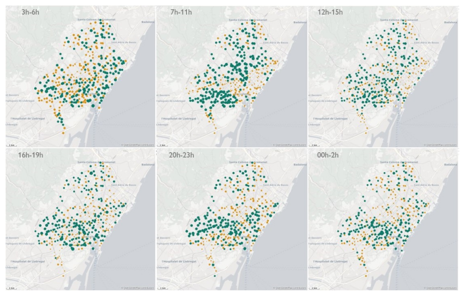

```python
import matplotlib.pyplot as plt
    from PIL import Image

    # Ruta de la imagen PNG
    ruta_imagen = 'C:/Users/gerar/Documents/Postgrau DSML/Capstone project/BicingBCN/Maps/diff findes/dif_franj.png'

    # Cargar la imagen
    imagen = Image.open(ruta_imagen)

    plt.figure(figsize=(12, 12))

    # Mostrar la imagen en el notebook
    plt.imshow(imagen)
    plt.axis('off')
    plt.show()
```

Distinguimos dos situaciones en función de la fanja horaria:

1. Se obsevan diferencias de en distintos puntos de la ciudad
2. **Las diferencias nos permiten prácticamente trazar fronteras muy claras**. Vamos a fijarnos en esto.

# Variación temporal

[figure not shown]

Este gráfico representa el promedio del mes de junio de 2022 del incremento acumulativo de las bicis que se han dejado durante todo un día de las bicis que se han dejado y las bicis que se han cogido en todas las estaciones de Bicing.

Los días escogidos han sido sólo los laborables, y el punto final implica el número de bicis que se han usado durante el día. Esta cifra puede oscilar de día en día laboravle entgre unos 4000 y 6000 bicicletas. Teniendo en cuenta que la información se recoge cada cinco minutos y los trayectos medios suelen durar 13,5 minutos, perdemos mucha información de bicicletas cogidas y dejadas. Por tanto, los datos reales deben ser bastante superiores a 1.239.482 según datos de Bicing.

Este patrón es el que corresponde a cualquier día laborable, variando según las condiciones de la cantidad total de bicis usadas

Se puede apreciar cómo a partir de las seis de la mañana hay un cambio de tendencia acumulada de las bicis que se cogen (veamos la línea roja) y se incrementa rápidamente hasta poco antes de las nueve de la mañana. A partir de ese momento, el ritmo de bicis cogidas se reduce y evoluciona de forma aproximadamente lineal hasta alrededor de las seis de la tarde, momento en que reduce el ritmo hasta quedar a cero a las doce de la noche.

El ritmo de crecimiento del número de bicicletas dejadas (línea azul) se mantiene mucho más activo durante las primeras horas de la madrugada. Esto está asociado a una especie de distribución de las bicicletas por la noche por la empresa, pero el motivo no está claro, sobre todo teniendo en cuenta las diferencias entre las bicis que se cogen

De la diferencia de las dos líneas (línea verde) son las bicicletas en uso. Se pueden apreciar dos picos alrededor de las 7:50 h y alrededor de las 8:50 h. Es el momento en que mucha gente que empieza su jornada sobre las 8 y 9h devuelve la bici a la estación, siendo mayoría las personas que empiezan a las 9 h. Otro pico se intuye sobre las 14:30, que puede estar relacionada con los viajes próximos (de ida o de vuelta) a la comida. Un último pico aparece alrededor de las 18:30, de la gente que vuelve a casa. A partir de esa hora, las bicis en uso van cayendo hasta cero.

[figure not shown]

Este gráfico es el equivalente al anterior para fines de semana. Podemos apreciar el número de bicicletas usadas se reduce un 25% aproximadamente.

También se observan diferencias en la dinámica de uso. Esta es mucho más suave que en el caso anterior. Se podría llegar a separar en tres zonas lineales. La primera des de las nueve de la mañana, con una pendiente menos elevada. A partir de las nueve se incrementa el uso de manera muy lineal hasta el pico de las ocho de la tarde, momento en el que se vuelven a reducir de manera similar a las primeras horas de la mañana.

Como observación, podríamos intuir un pico antes de las nueve del mediodía, pero no está claro de que se pueda asociar a nada en concreto.

# Vídeo aplicación

[video not shown]

# Creación del modelo, paso por paso

## **Descarga de Datos Bicing**

Los datos sobre el servicio de sharing de bicicletas, bicing, están disponibles en la web del Ajuntament de Barcelona, https://opendata-ajuntament.barcelona.cat/resources/bcn/BicingBCN . Los datos estan agrupados por meses y comprimidos con el formato {year}_{month:02d}_{month_name}_BicingNou_ESTACIONS.7z y se recopilan desde marzo de 2019. Para este proyecto, descargamos todos los datos del periodo marzo 2019 . diciembre 2022, que serán los datos que usaremos para el entrenamiento, los guardamos en formato csv, también por meses para su posterior procesamiento.

Cada uno de los ficheros contiene la siguiente información y tipo de dato:

**Variable**

**Tipo**

**Descripción**

**Min**

**Max**

**station_id**

int64

Identificador de la estación

1

532

**num_bikes_available**

int64

autoexplicativa

0

54 / 198*

**num_bikes_available_types.mechanical**

int64

autoexplicativa

0

54

**num_bikes_available_types.ebike**

int64

autoexplicativa

0

41

**num_docks_available**

int64

autoexplicativa

0

54 / 99*

**last_reported**

int64

Tiempo en segundos de cuando se tomó el registro

**is_charging_station**

bool

Si la estación permite cargar bicis eléctricas

**status**

object

```
IN_SERVICE
MAINTENANCE
PLANNED
NOT_IN_SERVICE
END_OF_LIFE
```

**is_installed**

int64

Si la estación está instalada

0

1

**is_renting**

int64

Si la estación permite la entrega(desbloquo) de bicicletas

0

1

**is_returning**

int64

Si la estación permite la devolución de bicicletas

0

1

**last_updated**

int64

Tiempo en segundos de la última actualización

**traffic (a partir de finales de 2021)**

float64

Desconocemos su significado, pero en la mayoría de casos o no está disponible o contiene NAN

**ttl**

int64

Variable descartable para este proyecto

Debido al gran tamaño de los ficheros, en un primer paso concatenamos los ficheros mensuales agrupando la información por años, salvando cada año en un fichero csv, y procedemos a analizar los datos año por año para ver qué tipo de datos tenemos y hacer un primer procesado descartando aquellas variables que consideremos innecesarias para este proyecto o transformando algunas de ellas.

Hacemos las siguientes observaciones:

- La variable **last_reported** no tiene registro en algunos casos (en 2019 por ejemplo). La descartaremos.
- Nos quedamos con la variable **last_udpated** para saber en qué momento se tomaron los datos, cambiaremos el formato a la fecha y hora correspondiente a nuestra zona horaria (timezone Europe/Madrid) creando las nuevas variables: **year, month, day, hour, min**
- Las variables **ttl** y **traffic** también las descartaremos. Está última variable no está recogida durante los primeros años, se incorpora a finalesl de 2021, pero en la mayoria de casos contine NAN
- Interpretamos los posibles valores de la variable **status** de la siguiente manera:
  - IN_SERVICE: estación en pleno funcionamiento
  - NOT_IN_SERVICE: estación temporalmente fuera de servicio. Puede ser por unas horas debido a algún evento o por varios dias debido a obras en la zona
  - MAINTENANCE: la estación está siendo asistida por el servicio de bicing, añadiendo o sustrayendo las bicicletas disponible en esa estación. Ese proceso dura unos minutos
  - PLANNED: estación planificada pero todavia no está en servicio.
  - END_OF_LIFE: estación suprimida

También observamos que el número de [ NOT_IN_SERVICE + MAINTENANCE + PLANNED] equivale al número de [**is_returning**==0] ; y que el número de [PLANNED] equivale al número [**is_installed**==0].

También vemos que cuando las estaciones tienen un estado distinto a IN_SERVICE los datos sobre **num_bikes_available**, **num_bikes_available_types.ebike**, **num_bikes_available_types.mechanical** y **num_docks_available** tienen inconsistencias. En la mayoria de casos num_bikes_available está a cero cuando el detalle bicicletas eléctricas y mecánicas dice lo contrario; y también hay varios casos con num_bike_available y num_docks_available ambos a cero. Además en esos casos no es posible devolver bicicletas como acabamos de comentar arriba, por lo que a efectos prácticos no hay docks disopnibles para el usuario. Por todo ello procederemos a eliminar los records en los que **status** != IN_SERVICE

- Detectamos 205 casos con datos incorrectos (todos los valores de bicicleta tienen el valor 99* ó 198*,claramente valores fuera de rango) de estaciones aparentemente en servicio en el **año 2020,** y alguno en **2021**. Procedemos a eliminarlos

Out[43]:

|  | station_id | num_bikes_available | num_bikes_available_types.mechanical | num_bikes_available_types.ebike | num_docks_available | is_installed | is_renting |
| --- | --- | --- | --- | --- | --- | --- | --- |
| 1110164 | 529 | 198 | 99 | 99 | 99 | 1 | 1 |
| 1110652 | 529 | 198 | 99 | 99 | 99 | 1 | 1 |
| ... | ... | ... | ... | ... | ... | ... | ... |
| 4386792 | 529 | 198 | 99 | 99 | 99 | 1 | 1 |
| 4387298 | 529 | 198 | 99 | 99 | 99 | 1 | 1 |

205 rows × 13 columns

Por último vemos que quedan algunos casos donde num_bikes_available y num_docks_available ambos están a cero, cuando la estación está IN_SERVICE. Esos casos en lugar de eliminarlos los estamos considerando como estaciones que no aceptan la devolución de bicicletas, como si estuvieran llenas.

|  | station_id | num_bikes_available | num_bikes_available_types.mechanical | num_bikes_available_types.ebike | num_docks_available | status | is_renting |
| --- | --- | --- | --- | --- | --- | --- | --- |
| 657079 | 79 | 0 | 0 | 0 | 0 | IN_SERVICE | 1 |
| 659099 | 79 | 0 | 0 | 0 | 0 | IN_SERVICE | 1 |
| ... | ... | ... | ... | ... | ... | ... | ... |
| 1643723 | 148 | 0 | 0 | 0 | 0 | IN_SERVICE | 1 |
| 2075695 | 394 | 0 | 0 | 0 | 0 | IN_SERVICE | 1 |

9591 rows × 13 columns

El formato de los ficheros .csv que guardamos con las información anual sobre el bicing, **Bicing_{year}.csv,** contendrá esta información:

| station_id | num_bikes_available | **num_bikes_available_types.mechanical** | **num_bikes_available_types.ebike** | num_docks_available | year | month | day | hour | min |
| --- | --- | --- | --- | --- | --- | --- | --- | --- | --- |

Estos ficheros serán los que usaremos para analizar con más detalle qué ocurrió en 2020 y cómo funciona el bicing en la actualidad, 2022, mostrando gráficas y mapas coloreads dinámicamente.

[figure not shown]

## Descarga megadatos de las estaciones

La información de cada estación en el año 2023, ubicación, dirección, capacidad, etc, está disponible en la web del ayuntamiento, en formato json. Descargamos el fichero, que contiene:

```
RangeIndex: 505 entries, 0 to 504
Data columns (total 14 columns):
 #   Column                  Non-Null Count  Dtype
---  ------                  --------------  -----
 0   station_id              505 non-null    int64
 1   name                    505 non-null    object
 2   physical_configuration  505 non-null    object
 3   lat                     505 non-null    float64
 4   lon                     505 non-null    float64
 5   altitude                505 non-null    float64
 6   address                 505 non-null    object
 7   post_code               505 non-null    object
 8   capacity                505 non-null    int64
 9   is_charging_station     505 non-null    bool
 10  nearby_distance         505 non-null    float64
 11  _ride_code_support      505 non-null    bool
 12  rental_uris             0 non-null      object
 13  cross_street            1 non-null      object
dtypes: bool(2), float64(4), int64(2), object(6)
```

y eliminamos los campos que no nos interesan (las marcadas en gris) y guardamos el resto en formato .csv para us uso posterior, por ejemplo filtrar los datos de los años a entrenar para que incluyan solo las estaciones válidas en 2023.

**WARNING ,** vemos que una de las estaciones no tiene información sobre la capacidad,. Buscamos dicha información, complementamos el dato y guardamos como **Informacio_Estacions_Bicing.csv**

[figure not shown]

## Postproceso de los datos para el training

Recuperamos los ficheros .csv por año que habíamos generado, concatenamos para obtener un único dataframe y seguimos con las transformaciones para obtener un dataframe de este tipo

|  | station_id | year | month | day | hour | capacity | altitude | percentage_docks_available | ctx-4 | ctx-3 | ctx-2 | ctx-1 |
| --- | --- | --- | --- | --- | --- | --- | --- | --- | --- | --- | --- | --- |
| 0 | 1 | 2019 | 3 | 28 | 22 | 46.0 | 16.0 | 0.021739 | 0.304348 | 0.280435 | 0.244565 | 0.054348 |
|  | ... | ... | ... | ... | ... | ... | ... | ... | ... | ... | ... | ... |

### Filtrado estaciones operativas en 2023

Filtramos los datos para quedarnos sólo con aquellos que correspondan a estaciones operativas en 2023 y en los año anteriores.

### Cálculo variable target

- Recuperamos el .csv con los metadatos de las estaciones y hacemos merge con el dataframe base para quedarnos con la capacidad.
- Creamos la variable target, **percentage_docks_available** como el porcentage de **num_docks_available** respecto la **capacity** de la estación. Detectamos pequeños errores, en algunos casos el número de docks es algo mayo que la capacidad y reajustamos el porcentage a 1

|  | station_id | year | month | day | hour | num_docks_available | capacity | percentage_docks_available |
| --- | --- | --- | --- | --- | --- | --- | --- | --- |
| 1034369 | 11 | 2022 | 1 | 11 | 20 | 35 | 34 | 1.029412 |
| 1035483 | 11 | 2022 | 1 | 15 | 18 | 35 | 34 | 1.029412 |

Solucionamos con esta instrucción,

dftotrain22.loc[(dftotrain22.percentage_docks_available > 1),'percentage_docks_available']=1

- Eliminamos la columnas que no necesitaremos: **num_bikes_available**, **num_bikes_available_types.mechanical**, **num_bikes_available_types.ebike**, **num_docsk_available**, **min**

### Cálculo columnas ctx-4, ctx-3, ctx-2, ctx-1

Con el objetivo de reducir el tamaño de los ficheros se propone en este caso añadir como variables lo porcentage de dock disponibles las horas previas, hasta 4 horas antes

- df=df.groupby(['station_id','year','month','day','hour'],as_index=False).mean(numeric_only=True)
- añadimos las columnas basadas en los porcentages anteriores  
  df['ctx-4'] = df['percentage_docks_available'].shift(periods=4, fill_value=0)  
  df['ctx-3'] = df['percentage_docks_available'].shift(periods=3, fill_value=0)  
  df['ctx-2'] = df['percentage_docks_available'].shift(periods=2, fill_value=0)  
  df['ctx-1'] = df['percentage_docks_available'].shift(periods=1, fill_value=0)
- eliminamos las filas intermedias puesto que la información ya se tiene en las variables adicionales  
  df_length, initial_row, row_increase = df.shape[0], 4, 5  
  df = df.iloc[initial_row:df_length:row_increase]

Ahora tenemos esto:

[figure not shown]

y la correspondiente descripción, cuyos valores nos parecen razonables:

[output not shown]

Por último, guardamos el fichero de training en formato csv con el nombre **Bicing_ToTrain.csv** para el poterior análisis, postproceso (añadir más variables), entrenamiento y finalmente selección del modelo:

## Carga datos meteorológicos

Creemos que disponer de algunos datos meteorológicos para el entrenamiento del modelo pueden ser de ayuda. Para ello accedemos a los datos históricos publicados por Meteocat, no són públicos pero se da acceso gratuito temporal para uso educativo, no lucrativo.

[figure not shown]

En Barcelona hay las siguientes estaciones meteorológicas automatizadas:

- Barcelona - el Raval: 'X4'
- Barcelona Zona Universitaria: 'X8'
- Barcelona - Observatori Fabra (Tibidabo): 'D5'
- Barcelona - Zoo (Ciutadella): 'X2' (només té variables sobre temperatura i humitat :( )
- Port de Barcelona - Bocana Sud: 'Y7' (al Prat de Llobregat)
- Port de Barcelona - ZAL Prat: 'Y9' (al Prat de Llobregat)

Dadas las ubicaciones de las estaciones de bicing, descartamos las ubicadas en el puerto de Barcelona. También descartamos la del Zoo de Barcelona puesto que solo recoge un par de datos: temperatura y humedad relativa. Nos descargamos de la web de meteocat los metadatos de las variables y de las estaciones meteorológicas para poder definir correctamente la URL de descarga e interpretar los valores de las variables meteorológicas.

Los datos se ofrecen para un dia y estación determinados (cada estación tiene un código). Procederemos a descargar los datos para todo el perido de entrenamiento, de marzo 2019 a diciembre de 2022, y luego para el set de predicción (primer trimestre de 2023) usando el código python:

import requests

key = 'LaClaveProporcionadaPorMeteocat';  
url0 = 'https://api.meteo.cat/xema/v1/estacions/mesurades'

**def get_meteocat_day_data**(codi, year, month, day):  
"""  
Function that downloads the data for a specific day of the year from meteocat website, converts it  
to a DataFrame and saves it to a csv file for future use. Sample of URL:

```
    https://api.meteo.cat/xema/v1/estacions/mesurades/X2/2022/02/01
```

NOTE: the number of queries to meteocat site is limited in the time, hence we save the info in csv files  
"""  
url_i = url0+'/{}/{}/{:02d}/{:02d}'.format(codi,year,month,day)  
print(url_i)  
response_i = requests.get(url_i, headers={"Content-Type": "application/json", "X-Api-Key": key})

assert (response_i.status_code == 200), f"response status code: {response_i.status_code}"  
dbmet = pd.read_json(response_i.text)  
**return** pd.json_normalize(dbmet['variables'][0], record_path=['lectures'],meta=['codi'])

Vamos leyendo la información por dia y estación y la guardamos agrupadas por meses, para mantener el paralelismo con los datos del bicing, con el formato {year}/{year}_{month:02d}_MeteoBCN{name}_{code}.csv

### Procesado datos meteorológicos

Los datos nos llegan con este formato, donde codi es el identificador de la variable meteorológica medida, y la base horaria es cada 30 minutos:

|  | data | dataExtrem | valor | estat | baseHoraria | codi |
| --- | --- | --- | --- | --- | --- | --- |
| 0 | 2020-12-01T00:00Z | 2020-12-01T00:00Z | 1018.6 | V | SH | 1 |
| 1 | 2020-12-01T00:30Z | 2020-12-01T00:37Z | 1018.5 | V | SH | 1 |
| 2 | 2020-12-01T01:00Z | 2020-12-01T01:11Z | 1018.4 | V | SH | 1 |
| ... | ... | ... | ... | ... | ... | ... |
| 1005 | 2020-12-31T22:30Z | 2020-12-31T22:30Z | 0.0 | V | SH | 72 |
| 1006 | 2020-12-31T23:00Z | 2020-12-31T23:00Z | 0.0 | V | SH | 72 |
| 1007 | 2020-12-31T23:30Z | 2020-12-31T23:30Z | 0.0 | V | SH | 72 |

La fecha está en formato UTC, por lo que tendremos que convertirla a formato time zone Europe/Madrid para mantener la coherencia con los datos del Bicing y poder concatenarlos correctamente..

Nos aseguramos que todos los datos estan verificados. De las más de 20 variables meteorológicas que se recogen por estación, usaremos solo las siguientes:

| Nombre | Unidades | Acrónimo | Código |
| --- | --- | --- | --- |
| Presión atmosférica | hPA | P | 34 |
| Temperatura | ºC | T | 32 |
| Humedad relativa | % | HR | 33 |
| Precipitación | mm | PPT | 35 |
| Velocidad viento | m/s | VV10 | 30 |
| Dirección viento | º | DV10 | 31 |
| Irradiancia solar | W/m² |  | 36 |

Recuperamos los datos salvados mensualmente por estación, los concatenamos agrupados por estación, descartamos dataExtrem, estat, y baseHoraria pues ya no los necesitamos, agrupamos los datos por fecha y hora , pivotamos la tabla para que las variables queden como columnas, reemplazamos los códigos (numéricos) por el acrónimo correspondiente, y salvamos temporalmente en un dataframe por estación.

Por último unificamos en un solo dataframe, calculando la media de las tres estaciones consideradas y salvamos en un fichero para posterior uso, con el nombre **All_MeteoBCN.csv**

Para el training sólo usaremos los datos que van de marzo 2019 a dicembre 2022, mientras que los del primer trimestre de 2023 se dejaran para la predicción.

Cuando unamos estos datos a los del training tendrá este aspecto:

|  | year | month | day | hour | RS | PPT | P | HR | T | DV10 | VV10 |
| --- | --- | --- | --- | --- | --- | --- | --- | --- | --- | --- | --- |
| 0 | 2019 | 3 | 1 | 0 | 0.0 | 0.0 | 1003.600000 | 80.666667 | 12.000000 | 197.333333 | 1.200000 |
| 1 | 2019 | 3 | 1 | 1 | 0.0 | 0.0 | 1003.566667 | 77.000000 | 12.100000 | 195.000000 | 0.700000 |
| 2 | 2019 | 3 | 1 | 2 | 0.0 | 0.0 | 1003.466667 | 79.000000 | 11.633333 | 250.666667 | 0.900000 |
| ... | ... | ... | ... | ... | ... | ... | ... | ... | ... | ... | ... |
| 35802 | 2023 | 3 | 31 | 23 | 0.0 | 0.0 | 996.633333 | 74.666667 | 14.433333 | 63.333333 | 3.233333 |
| 35803 | 2023 | 4 | 1 | 0 | 0.0 | 0.0 | 996.700000 | 77.333333 | 14.100000 | 78.333333 | 2.466667 |
| 35804 | 2023 | 4 | 1 | 1 | 0.0 | 0.0 | 996.900000 | 80.333333 | 13.866667 | 124.000000 | 1.500000 |

## Carga datos transporte público y distancia a las playas

También creemos que conocer cuántas paradas de transporte público, bus o metro, quedan cerca de una estación de bicing puede contribuir al modelo de predicción. Para ello accedemos a los datos publicados por el Ajuntament de Barcelona https://opendata-ajuntament.barcelona.cat/resources/bcn/GuiaBCN/TRANSPORTS.csv y usando la ubicación de cada estación (latitud y longitud) y la de las paradas de transporte, calculamos las que quedan a menos de medio kilómetro de cada estación, las contamos y asignamos un número entero a cada estación.

De forma similar procedemos para calcular la distància, en metros, de cada estación a las playas:  
'Platja de Sant Sebastià',  
'Platja de la Nova Icària',  
'Platja del Somorrostro',  
'Platja de la Barceloneta',  
'Platja de la Nova Mar Bella',  
'Platja de Llevant',  
'Platja del Bogatell',  
'Platja de Sant Miquel',  
'Zona de Banys'

Estas dos nuevas variables las añadimos al fichero de metadatos de las estaciones, **Informacio_Estacions_Bicing.csv**, para posteriormente añadirlo al training o a los datos a predecir si finalmente se tienen en cuenta, y se llamarán **n_transp_500m** y **min_dist_to_beach**. El aspecto del dataframe cuando lo carguemos será:

|  | station_id | name | lat | lon | altitude | address | post_code | capacity | n_transp_500m | min_dist_to_beach |
| --- | --- | --- | --- | --- | --- | --- | --- | --- | --- | --- |
| 0 | 1 | GRAN VIA CORTS CATALANES, 760 | 41.397978 | 2.180107 | 16.0 | GRAN VIA CORTS CATALANES, 760 | 8013 | 46 | 3.0 | 2048.805533 |
| 1 | 2 | C/ ROGER DE FLOR, 126 | 41.395488 | 2.177198 | 17.0 | C/ ROGER DE FLOR, 126 | 8013 | 29 | 11.0 | 2012.807353 |
| ... | ... | ... | ... | ... | ... | ... | ... | ... | ... | ... |
| 503 | 518 | C/ LLOBREGÓS, 115 | 41.424689 | 2.157049 | 112.0 | C/ LLOBREGÓS, 115 | 8032 | 27 | 4.0 | 5370.528992 |
| 504 | 519 | C/ PEDRELL, 52 | 41.424655 | 2.166289 | 110.0 | C/ PEDRELL, 52 | 8032 | 24 | 0.0 | 4777.728819 |

## Carga datos festivos y eventos

|  | date |
| --- | --- |
| 0 | 2019-01-01 |
| 1 | 2019-01-05 |
| 2 | 2019-04-19 |
| ... | ... |
| 69 | 2023-12-25 |
| 70 | 2023-12-26 |

Usaremos estos datos para crear en el fichero de training una variable 0/1 llamada holiday

## Carga datos adicionales

Además de los datos mencionados anteriormente, creemos interesante añadir algunas variables más al dataset de training:

### Metadatos de las estaciones

Incorporaremos las siguientes variables de los metadatos de las estaciones:

- **altitude**
- **capacity**
- **post_code**

### Variables obtenidas a partir de los datos iniciales del dataset de training

Del análisis hecho de los datos concluimos que las siguientes variables, calculadas a partir de las fechas , se deberían incluir:

### Zonas de estaciones de bicicletas

Como usuarios del bicing y también analizando los datos hemos visto que ciertas estaciones parecen tener un comportamiento similar a lo largo del tiempo. Tenemos problemas computacionales si aplicamos OneHotEncoder a variables con muchos valores, por ejemplo a station_id (505 opciones), por lo que decidimos agrupar las estaciones en cinco tipos. La variable se llamará **zone** y los valores posibles son:

- **bicing_platges**: todas las estaciones cerca de la playa
- **bicing_pcatalunya**: todas las estaciones del centro y alrededor incluyendo universidad de Barcelona, plaza Urquinaona..centro
- **bicing_uni**: las estaciones alreadedor de la zona universitaria diagonal
- **bicing_alta**: las estaciones que se encuentra a más de 60 metros del nivel del mar (subir cuesta arriba puede ser un inconveniente a usar el bicing)
- **bicing_other**: el resto de estaciones

Finalmente cargamos nuestro dataframe de training inicial con todas las variables mencionadas anteriormente. Para ellos crearemos un pipeline, add_features, para poder añadir estas variables también al conjunto de test o validación, y a las futuras predicciones que queramos hacer. Si finalmente alguna de las variables mencionadas anteriormente no se incluyera en el modelo, corregiríamos el pipeline. El aspecto que tendrá nuestro dataframe de training ahora será:

|  | station_id | year | month | day | hour | capacity | altitude | percentage_docks_available | ctx-4 | ctx-3 | ... | holiday | season | zone | RS | PPT | P | HR | T | DV10 | VV10 |
| --- | --- | --- | --- | --- | --- | --- | --- | --- | --- | --- | --- | --- | --- | --- | --- | --- | --- | --- | --- | --- | --- |
| 0 | 1 | 2019 | 3 | 28 | 22 | 46.0 | 16.0 | 0.021739 | 0.304348 | 0.280435 | ... | 0 | 1 | other | 0.000000 | 0.0 | 1007.433333 | 65.666667 | 11.433333 | 283.666667 | 1.766667 |
| 1 | 1 | 2019 | 3 | 29 | 3 | 46.0 | 16.0 | 0.000000 | 0.009058 | 0.003623 | ... | 0 | 1 | other | 0.000000 | 0.0 | 1006.266667 | 47.333333 | 10.800000 | 307.666667 | 2.866667 |
| 2 | 1 | 2019 | 3 | 29 | 8 | 46.0 | 16.0 | 0.432971 | 0.009058 | 0.007246 | ... | 0 | 1 | other | 247.333333 | 0.0 | 1007.366667 | 53.666667 | 11.900000 | 118.000000 | 1.733333 |
| ... | ... | ... | ... | ... | ... | ... | ... | ... | ... | ... | ... | ... | ... | ... | ... | ... | ... | ... | ... | ... | ... |
| 2972603 | 519 | 2022 | 12 | 31 | 13 | 24.0 | 110.0 | 1.000000 | 0.871528 | 0.902778 | ... | 0 | 4 | alta | 430.333333 | 0.0 | 1003.866667 | 37.000000 | 20.700000 | 259.000000 | 2.633333 |
| 2972604 | 519 | 2022 | 12 | 31 | 18 | 24.0 | 110.0 | 0.906250 | 0.965278 | 0.944444 | ... | 0 | 4 | alta | 0.000000 | 0.0 | 1004.066667 | 72.000000 | 15.300000 | 244.666667 | 2.033333 |
| 2972605 | 519 | 2022 | 12 | 31 | 23 | 24.0 | 110.0 | 0.583333 | 0.885417 | 0.760417 | ... | 0 | 4 | alta | 0.000000 | 0.0 | 1005.466667 | 73.333333 | 13.633333 | 111.000000 | 1.966667 |

Comprobamos si tenemos valores nulos, y encontramos que dos variables sí. Veremos más adelante cómo lo tratamos.

Out[52]:

```
Index(['n_transp_500m', 'min_dist_to_beach'], dtype='object')
```

# **Visualización de los datos**

Como las incorporaciones que hemos hecho, vamos a ver ahora qué forma tienen todos nuestros datos y correlación entre ellos

[figure not shown]

- Vemos que de algunas estaciones hay menos registros, pero es correcto pues algunas estaciones de 2023 se activaron en 2020, 2021 e incluso algunas en 2022
- Tenemos menos registros en 2019 y 2020 que en 2021 y 2022 donde los registrados son muy similares. La razón, el registro de esta información pública se inicia a finales de marzo de 2019 (casi tres meses menos de registros) y en 2020 debido a la pandemia el servicio también estuvo unas semanas desactivado. Cuando miramos los datos por mesos, apreciamos también esas diferencias.
- Si analizamos por dias del mes, tenemos números de registros bastante similares.
- Por horas el número de registros es prácticamente igual, eso nos va muy bien para entrenar el modelo
- Ampliamos PPT

[figure not shown]

### **Outliers**

Pasamos a analizar con más detalle las variable meteorológicas, min_dist_to_beach, n_transp_500m y la variable target percentange_docks_available

[figure not shown]

La **temperatura(T)** y **dirección del viento(DV10)** no tienen outliers, el resto sí. Analizamos con más detalle las variables **PPT** (precipitación) y **VV10** (velocidad del viento)

[figure not shown]

La precipitación ha sido tan escasa en el período considerado (especialmente seco) que los registros con lluvia de por sí ya son outliers. No aplicaremos la transformación basada en los quantiles en estes caso, y estandarizaremos la variable para mitigar el impacto de esos valores tan dispares, pero como veremos más adelante, ésta es una variable que finalmente no se incluirá en el modelo.

Por otra parte, **min_dist_to_beach** no tiene outliers, y **n_transp_500m** algunos que también trataremos

[figure not shown]

La variable target, como vemos debajo, no tiene outiers, y las variables ctx-4, ctx-3, ctx-2, y ctx-1 obtenidas a partir de la variable target tampoco, como era de esperar

[figure not shown]

### **Transformaciones**

Después de analizar las gráficas nos planteamos las siguientes transformaciones, donde **Replace_Outliers_2_NaN** es una función que calcula los límites superiore e inferior a partir de los quantiles 75% y 25% y todos los valores por encima o por debajo se redefinen como NaN.

Todos los NaN de cada variable se reemplazarán por el valor de la mediana de dicha variable. Todas las variables numéricas serán también estandarizadas

variables numéricas

num1_attribs=['**altitude**','**PPT**']  
num1_pipeline = Pipeline([  
('imputer', **SimpleImputer**(strategy="median")),  
('log',FunctionTransforme**r**(**np.log1p**)),  
('std_scaler', **StandardScaler**()),  
])

num2_attribs = ['**capacity**','**T**','**min_dist_to_beach**']  
num2_pipeline = Pipeline([  
('imputer', **SimpleImputer**(strategy="median")),  
('std_scaler', **StandardScaler**()),  
])

num3_attribs=['ctx-4','ctx-3','ctx-2','ctx-1','weekend','peekhour','holiday'] #passthrough

num4_attribs=['**n_transp_500m**','**HR**','**VV10**','**P**','**RS**']  
num4_pipeline = Pipeline([  
('replace_outliers',**Replace_Outliers_2_NaN**()),  
('imputer', **SimpleImputer**(strategy="median")),  
('std_scaler', **StandardScaler**()),  
])

variabales que pasan a ser tratadas como categóricas

cat1_attribs = ['**station_id**','**post_code**','**year**','**month**','**hour**','**season**']  
cat1_pipeline = Pipeline([  
('transform_to_Cat',FunctionTransformer(func = **transform_Num_to_Cat**,validate=False)),  
('imputer', **SimpleImputer**(strategy="constant",fill_value='Unknown')),  
('ordinal_encoder', **OrdinalEncoder**()),  
])  
cat2_attribs=['**zone**'] #ja era categòrica  
cat2_pipeline = Pipeline([  
('imputer', **SimpleImputer**(strategy="constant",fill_value='Unknown')),  
('one_hot_encoder', **OneHotEncoder**(handle_unknown='ignore')),  
])

unimos todas las transformaciones

full_pipeline = ColumnTransformer([  
("num1", num1_pipeline, num1_attribs),  
("num2", num2_pipeline, num2_attribs),  
("cat1", cat1_pipeline, cat1_attribs),  
("cat2", cat2_pipeline, cat2_attribs),  
("num3", 'passthrough', num3_attribs),  
("num4", num4_pipeline, num4_attribs),  
])

### **Correlación entre las distintas variables y percentage_docks_avaialble**

[figure not shown]

Las variables **ctx-4**, **ctx-3**, **ctx-2** y **ctx-1** están fuertemente correlacionadas con la variable target, percentage_docks_available, como era de esperar por la manera en que se han calculado.

La variable del tiempo **RS** (Irradiancia solar global) está bastante correlacionada con **HR**(humedat relativa) y con **T**(temperatura). Nos planteamos prescindir de RS.

Como punto de partida prescindiremos de la variable **DV10**(dirección del viento).

**altitude** y **min_dist_to_beach** tienen correlación con la variable target, y aunque entre ellas están fuertemente correlacionadas puesto que las estacioneos en la playa tienen altitud cero o casi, su significado es bien distinto pq el uso de las estaciones de bicicletas de la zona de playa no viene influenciado directametne por la altura (nivel del mar) a la que estan sinó por encontrarse en un sitio de mucho interés en el tiempo libre.

# **Modelo: selección, entrenamiento, scores**

### **Estratificación, split train - test**

Es momento de proceder a dividir el dataset entre la parte que usaremos para el entrenamiento y la parte que reservaremos para validar el modelo (test). Para asegurarnos que ambos sets mantienen la misma proporción de tipos de datos, evaluamos varias formas de estratificar los datos:

- Opción 1 ['**station_id**','**month**','**hour**','**day**'] : no funciona (obtenemos el error ValueError: The least populated class in y has only 1 member, which is too few. The minimum number of groups for any class cannot be less than 2.)
- Opción 2 ['**year**','**month**','**hour**','**day**'] : realizamos un primer entrenamientos con una simple regresión lineal y vemos que nos ayuda a hacer una mejor predicción, con menos error MSE
- Opción 3 ['**month**','**hour**','**day**'] : mejores resultados que si no estratificamos, pero no mejora la opción anterior
- Opción 4 ['**disponibilitat**'] : creamos una variable categórica a partir de la variable target, percentage_docks_available, que nos clasifica cada estación en 5 categorías posibles según el nivel de disponibilidad de docks:

Out[43]:

```
['força ple', 'ple', 'mig buit', 'quasi buit', 'buit']
Categories (5, object): ['ple' < 'força ple' < 'mig buit' < 'quasi buit' < 'buit']
```

Procedemos a estratificar según opción 4 y a continuación eliminamos las variables target y la categórica disponibilitat usada para estratificar, pues no deben incluirse como variables de entrenamiento,. También comprobamos shape de ambos datasets :

In [55]:

```
labels=bicing['percentage_docks_available'].copy()
```

In [56]:

```
labels.isna().any()
```

Out[56]:

```
False
```

In [57]:

```
X_train, X_test, y_train, y_test = train_test_split(bicing,labels,test_size=.2,random_state=seed,shuffle=True,stratify=bicing['disponibilitat'])
```

In [58]:

```
for set_ in (X_train, X_test):
```

```
    set_.drop(columns=['percentage_docks_available','disponibilitat'],inplace=True)
```

In [59]:

```
Training Shape: X (2378084, 26) , y: (2378084,)
Testing Shape: X (594522, 26) , y: (594522,)
```

El dataset de entrenamiento, **X_train**, tiene este aspecto:

|  | station_id | year | month | day | hour | capacity | altitude | ctx-4 | ctx-3 | ctx-2 | ... | holiday | season | zone | RS | PPT | P | HR | T | DV10 | VV10 |
| --- | --- | --- | --- | --- | --- | --- | --- | --- | --- | --- | --- | --- | --- | --- | --- | --- | --- | --- | --- | --- | --- |
| 1307303 | 221 | 2022 | 11 | 7 | 17 | 24.0 | 68.0 | 0.881410 | 0.906250 | 0.850694 | ... | 0 | 4 | other | 23.666667 | 0.000000 | 997.766667 | 75.666667 | 17.566667 | 231.000000 | 2.300000 |
| 126916 | 22 | 2021 | 8 | 22 | 15 | 19.0 | 28.0 | 0.732456 | 0.832536 | 0.688596 | ... | 0 | 3 | other | 689.333333 | 0.000000 | 1000.266667 | 65.333333 | 28.233333 | 159.666667 | 3.000000 |
| ... | ... | ... | ... | ... | ... | ... | ... | ... | ... | ... | ... | ... | ... | ... | ... | ... | ... | ... | ... | ... | ... |
| 155335 | 27 | 2019 | 10 | 2 | 21 | 21.0 | 38.0 | 0.869048 | 0.892857 | 0.944444 | ... | 0 | 4 | other | 0.000000 | 0.000000 | 994.200000 | 68.000000 | 20.133333 | 109.000000 | 2.033333 |
| 1912954 | 319 | 2020 | 1 | 20 | 13 | 31.0 | 51.0 | 0.271505 | 0.352151 | 0.403226 | ... | 0 | 1 | other | 135.333333 | 0.000000 | 1004.133333 | 57.000000 | 8.566667 | 60.333333 | 9.866667 |

### **Column Transformers**

Procedemos a aplicar las transformaciones comentadas en la sección anterior: fit & transform al set de entrenamiento , y sólo transform al set de validación. Comprobamos que mantenemos las mismas dimensiones de los sets:

train_prepared = full_pipeline.**fit_transform**(X_train)

Out[186]:

```
array([[ 1.12779005, -0.12501115, -0.47456499, ..., -0.02281921,
         0.21363936, -0.33404425],
       [ 0.2531122 , -0.12501115, -1.25540877, ..., -0.09947645,
        -0.02402338, -0.49281287],
       [-0.28581762,  0.45802176, -0.94307126, ..., -0.09947645,
        -0.02402338, -0.49281287],
       ...,
       [ 0.91714057, -0.12501115, -0.47456499, ..., -0.09947645,
        -0.02402338, -0.49281287],
       [ 0.55206692, -0.12501115, -0.94307126, ..., -0.32944819,
        -0.69457182, -0.49281287],
       [ 0.84236   , -0.12501115,  0.61861632, ..., -0.09947645,
        -0.02402338, -0.49281287]])
```

train_prepared.shape

Out[187]:

```
(2378084, 28)
```

test_prepared = full_pipeline.**transform**(X_test)

Out[188]:

```
(594522, 28)
```

### **Entrenamiento**

Hacemos un primer entrenamiento con los siguientes modelos:

- Linea Regression
- KNeighborsRegressor
- RandomForestRegressor
- GradientBoostingRegressor

El estadístico que usaremos para comparar el funcionamento de cada modelo es Mean Square Error. Parece que los mejores modelos son Random Forest Regressor y Gradient Boosting Regressor, pero procedemos a realizar un cross_validation con 10 folks, para valorar el funcionamiento en promedio según va variando la parte sobre la que se hace el training. Los resultados obtenidos son:

[figure not shown]

### **Búsqueda de los mejores hiperparámetros**

Por ahora parece que el mejor modelo es Random Forest Regressor. Procedemos a hacer una búsqueda para encontrar los mejore hiperparámetros. También en este caso aplicaremos k-fold (pero más pequeño pues nos enfrentamos a limitaciones computacionales de nuestros laptops).

[figure not shown]

**Score predicción set de validación con Random Forest Regressor**

```
MSE (train | test):
0.0049602399223658096   0.010040911898578834
R2 (train | test):
0.9303457191788437   0.8534793570213218
```

[figure not shown]

Dado que no había mucha diferencia entres los estimadores Random Forest Regresso y **Grandient Boosting Regressor**, exploramos de nuevo el segundo estimador y buscamos los mejores hiperparámetros , para ver si mejoramos resultados. El mejor resultado lo obtenemos con

GradientBoostingRegressor(n_estimators=2000,random_state=seed,max_depth=6)

**Score predicción set de validación con Gradient Boosting Regressor**

MSE (train | test):  
0.009707910879462097 0.009752140802141927  
R2 (train | test):  
0.8641781895663517 0.863633803236243

[figure not shown]

Como podemos ver, el peso de los parámetros es muy distinto a los obtenido con el estimador Random Forest Regressor.

Decidimos exploramos un estimador más, **XGBoost,** que es el que mejor nos acaba funcionando. Después de obtener los primeros resultados, vemos que las variables '**season**' (muy correlacionada con la variable 'hour') y '**ppt**' no tienen apenas peso, y probamos eliminándolas, lo cual nos da una lijera mejor del modelo:

**import** xgboost **as** xgb  
xgb_model = xgb.XGBRegressor(n_estimators=**1000**, early_stopping_rounds=**10**)

xgb_model.fit(train_prepared, y_train, eval_set=[(train_prepared, y_train), (test_prepared, y_test)], verbose=50)

```
[0]	    validation_0-rmse:0.22157	validation_1-rmse:0.22145
[50]	validation_0-rmse:0.10083	validation_1-rmse:0.10044
[100]	validation_0-rmse:0.09930	validation_1-rmse:0.09926
[150]	validation_0-rmse:0.09835	validation_1-rmse:0.09863
[200]	validation_0-rmse:0.09769	validation_1-rmse:0.09826
[250]	validation_0-rmse:0.09705	validation_1-rmse:0.09793
[300]	validation_0-rmse:0.09647	validation_1-rmse:0.09766
[350]	validation_0-rmse:0.09608	validation_1-rmse:0.09757
[400]	validation_0-rmse:0.09571	validation_1-rmse:0.09750
[450]	validation_0-rmse:0.09529	validation_1-rmse:0.09737
[500]	validation_0-rmse:0.09486	validation_1-rmse:0.09722
[550]	validation_0-rmse:0.09451	validation_1-rmse:0.09716
[556]	validation_0-rmse:0.09449	validation_1-rmse:0.09716
```

results=xgb_model.evals_result()  
plt.plot(results['validation_0']['rmse'], label='train')  
plt.plot(results['validation_1']['rmse'], label='test')  
plt.legend()  
plt.show()

```
Score predicción set validación con XGBoost
```

[figure not shown]

# Make predictions  
y_train_xgb = xgb_model.predict(train_prepared)

test_prepared=full_pipeline.transform(X_test)

y_test_xgb = xgb_model.predict(test_prepared)

```
# Compute MSE for training and testing sets
print('MSE (train | test):')
print(mean_squared_error(y_train_xgb, y_train), mean_squared_error(y_test_xgb, y_test))
print('R2 (train | test):')
print(r2_score(y_train_xgb, y_train), r2_score(y_test_xgb, y_test))

MSE (train | test):
0.008935940587087248 0.009439234663387547
R2 (train | test):
0.8761112236824559 0.8690996304193535
```

# Intervalo de confianza del set de test  
**from** scipy **import** stats  
confidence = 0.95  
squared_errors = (y_test_xgb - y_test) ** 2  
stats.t.interval(confidence, len(squared_errors) - 1,  
loc=squared_errors.mean(),  
scale=stats.sem(squared_errors))

(0.009365907226865578, 0.009512562099909517)

**Feature importance con XGBoost**

## Best features according to XGBoost  
feature_importances = xgb_model.feature_importances_  
cat_one_hot_attribs = list(full_pipeline.named_transformers_["cat2"]['one_hot_encoder'].categories_[0])  
attributes = num1_attribs+num2_attribs+cat1_attribs+cat_one_hot_attribs+num3_attribs+num4_attribs  
list_sorted=sorted(zip(feature_importances, attributes), reverse=**True**)  
list_sorted

```
[(0.8550421, 'ctx-1'),
 (0.01757553, 'peekhour'),
 (0.01756528, 'ctx-2'),
 (0.0119349705, 'pcatalunya'),
 (0.009942545, 'hour'),
 (0.009657315, 'other'),
 (0.0093416255, 'uni'),
 (0.007731035, 'platges'),
 (0.0076978267, 'altitude'),
 (0.00678102, 'min_dist_to_beach'),
 (0.0067344415, 'weekend'),
 (0.0062929047, 'post_code'),
 (0.0045238584, 'year'),
 (0.0035329368, 'capacity'),
 (0.00350229, 'holiday'),
 (0.0034527145, 'n_transp_500m'),
 (0.0032340602, 'station_id'),
 (0.0030224612, 'RS'),
 (0.0027051193, 'alta'),
 (0.0023601355, 'month'),
 (0.0022260565, 'ctx-3'),
 (0.0020159995, 'ctx-4'),
 (0.0016728155, 'T'),
 (0.0014549182, 'HR')]
```

[figure not shown]

## **Explicación del modelo:**

La variable que mayormente define el modelo, más de un 80%, es el estado de la estación la hora previa a la predicción.

Del resto de variables, las que más peso tienen son:

- la hora del dia, y sobretodo si es hora punta ( de 8 a 10 de la mañana y de 5 a 7 de la tarde). Esta información ya se intuyó en el análisis inicial de los datos
- la situación de la estación dos horas antes
- la clasificación en cinco grupos que hemos hecho de las estaciones: las del centro (pcatalunya), las de la zona de playas, las de la zona universitaria (diagonal), las que se encuentran a más de 60 m del nivel del mar, y el resto, han contribuido claramente a definir el modelo de predicción. Nos está diciendo que cada una de estas zonas tienen un comportamiento parecido.
- Que sea fin de semana o no y la altitud a la que se encuentra la estación también contribuyen
- Las variables meteorológicas son las que tienen menos influencia, los días/horas con radiación solar (RS) muy fuerte puede afectar al uso de la bicicleta, pero en general el tiempo no parece tener un peso relevante, quizás por la climatologia de nuestra ciudad, poca lluvia y pocos dias muy frios

# Presentación completa

[figure not shown]